# Donor Profile: AICS - Agenzia Italiana per la Cooperazione allo Sviluppo / Italian Agency for Cooperation and Development

## Focus Portfolio

The 2025 portfolio of AICS highlights significant funding imbalances across UNHCR regions, with total donor contributions ranging from just over 1M€ to 8.6M€. This variability signals both a challenge and a strategic opportunity: regions with lower funding represent untapped potential where targeted donor engagement could serve as an impact multiplier. Specifically, the mean funding level of approximately 3.8M€ and a high standard deviation of 2.6M€ indicate funding concentration that, if diversified, can increase programmatic resilience and scalability. Investing to equalize support across all five key regions will enhance emergency response capacities and foster long-term development partnerships. We recommend prioritizing strategic outreach and co-funded initiatives in underfunded areas to leverage AICS’s operational footprint and demonstrate measurable impact, supporting accountability and innovation priorities that resonate with major donors. Immediate action is essential to mitigate risks of resource gaps that may undermine program outcomes and to capitalize on emerging collaboration opportunities. Decision-makers are urged to allocate flexible funding, emphasizing equitable distribution and partnership diversification to optimize portfolio impact and align with donor strategic priorities.

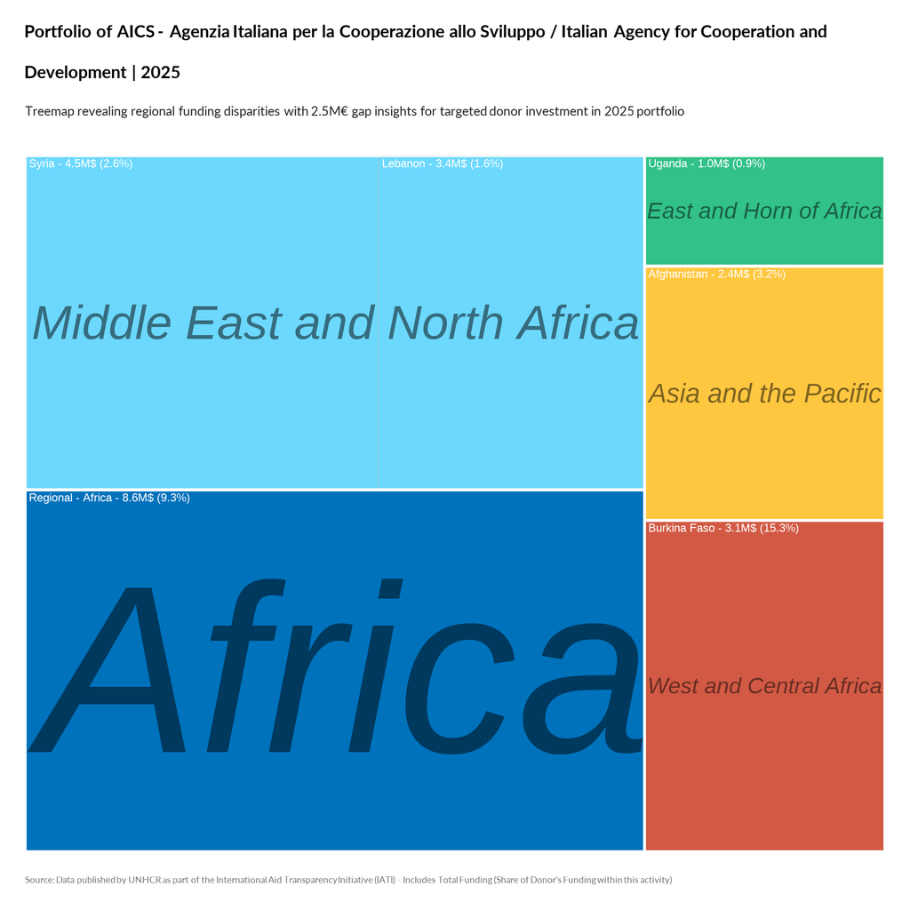

TRUE

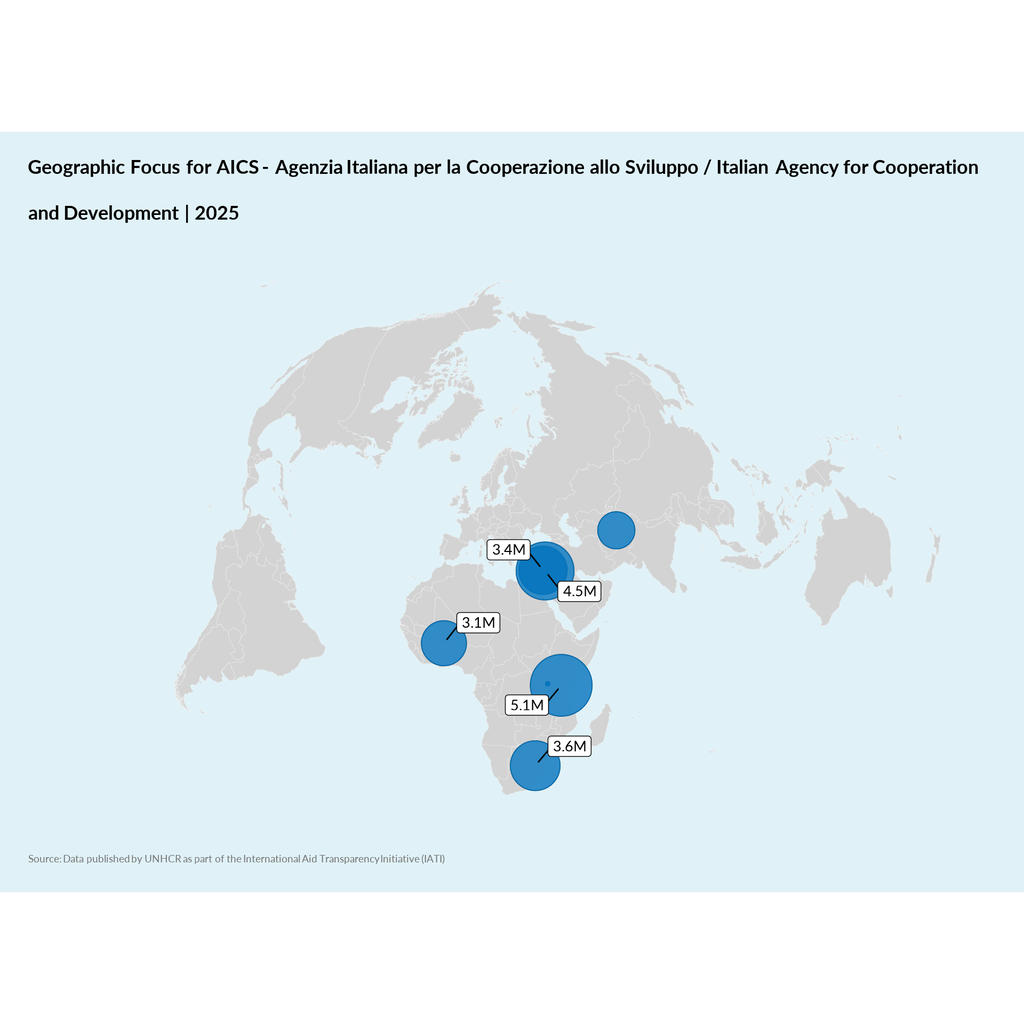

TRUE